[GitHub](https://github.com/JuliaGeometry/DelaunayTriangulation.jl)[](https://github.com/JuliaGeometry/DelaunayTriangulation.jl/tree/main/docs/src/literate_tutorials/operations_legalise_edge.jl)

# Triangulation Operations

## Legalising an Edge

One important procedure, used for example in the paper *Randomized Incremental Construction of Delaunay and Voronoi Diagrams* by Guibas et al., 1992 (which is also the algorithm discussed by de Berg et al. in the book *Computational Geometry: Algorithms and Applications* (3 ed., 2008)), is the legalising of an edge. This isn't used anywhere in the package directly, but perhaps you might need it (for example, to implement the above algorithm). The idea is that we may sometimes have edges that are not Delaunay, meaning *illegal*, and we want to somehow fix them to be Delaunay, which may also require fixes to nearby edges after fixing the initial edge. In this way, we are *legalising* the edge. (The edge $e_{ij}$ is *illegal* if the circle through $p_i$, $p_j$, and $p_k$ contains $p_r$ in its interior, where $p_k$ and $p_r$ are the other points on the triangles adjoining $e_{ij}$.)

We provide a function `legalise_edge!` for this procedure, and the function assumes that there is a point `r` that has been inserted inside some triangle `(i, j, k)`; the legality of an edge is checked using `DelaunayTriangulation.is_legal`. The function then helps to restore the Delaunay property of the triangulation following such an insertion; this is the main step of the algorithm of Guibas et al. (1992) above.

We use this tutorial to demonstrate how this can be used. First, let us define some initial triangulation.

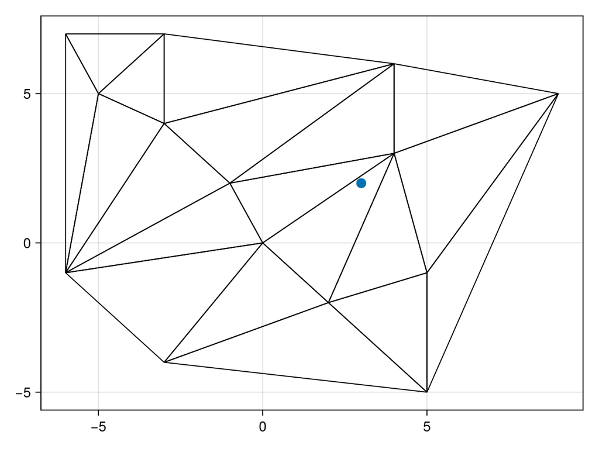

```julia
using DelaunayTriangulation
using CairoMakie

points = [
    (-1.0, 2.0), (4.0, 6.0), (4.0, 3.0), (-3.0, 7.0),
    (-6.0, -1.0), (9.0, 5.0), (5.0, -5.0), (-6.0, 7.0),
    (0.0, 0.0), (-3.0, 4.0), (-5.0, 5.0), (-3.0, -4.0),
    (5.0, -1.0), (2.0, -2.0)
]
p = (3.0, 2.0)
tri = triangulate(points)
fig, ax, sc = triplot(tri)
scatter!(ax, [p], markersize=14)
fig
```

The blue point is the point to be added. It is inside the triangle `(9, 14, 3)`. To insert it, follow Guibas et al. (1992) and connect the edges of `(9, 14, 3)` to the new point. This is done using `split_triangle!`. (Note: the function `DelaunayTriangulation.complete_split_triangle_and_legalise!` does the splitting and the legalising all in the same step, but we do not demonstrate this here.)

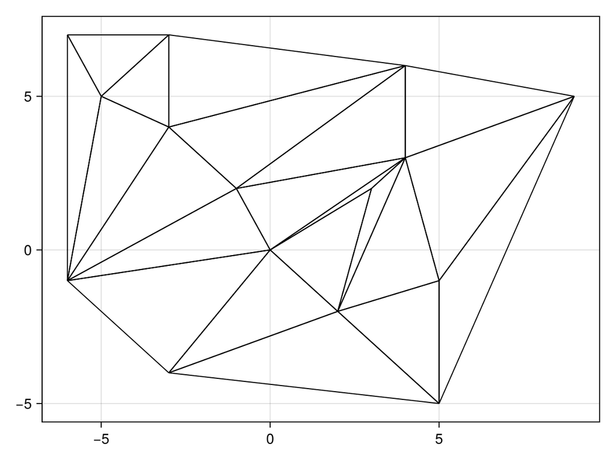

```julia
push!(points, p)
r = length(points)
i, j, k = 9, 14, 3
split_triangle!(tri, i, j, k, r)
fig, ax, sc = triplot(tri)
fig
```

This splitting introduces some new illegal edges, shown in red below.

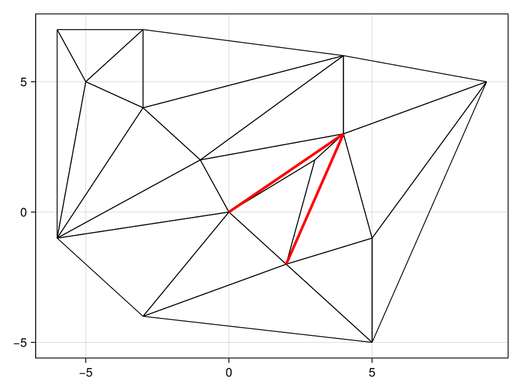

To fix this, we use `legalise_edge!`. This functions take in a single edge, so to legalise all the new edges we apply the function to each edge of the triangle that the point resides in. (The function `DelaunayTriangulation.legalise_split_triangle!` also performs these three calls below.)

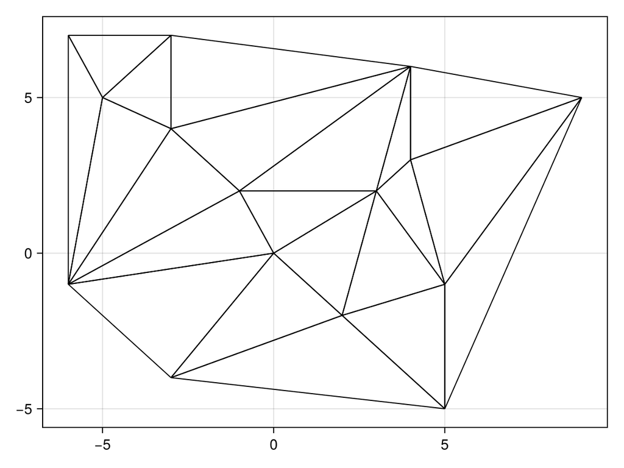

```julia
legalise_edge!(tri, i, j, r)
legalise_edge!(tri, j, k, r)
legalise_edge!(tri, k, i, r)
fig, ax, sc = triplot(tri)
fig
```

The triangulation is now Delaunay, and there are no more illegal edges.

## Just the code

An uncommented version of this example is given below. You can view the source code for this file [here](https://github.com/JuliaGeometry/DelaunayTriangulation.jl/tree/main/docs/src/literate_tutorials/operations_legalise_edge.jl).

```julia
using DelaunayTriangulation
using CairoMakie

points = [
    (-1.0, 2.0), (4.0, 6.0), (4.0, 3.0), (-3.0, 7.0),
    (-6.0, -1.0), (9.0, 5.0), (5.0, -5.0), (-6.0, 7.0),
    (0.0, 0.0), (-3.0, 4.0), (-5.0, 5.0), (-3.0, -4.0),
    (5.0, -1.0), (2.0, -2.0)
]
p = (3.0, 2.0)
tri = triangulate(points)
fig, ax, sc = triplot(tri)
scatter!(ax, [p], markersize=14)
fig

push!(points, p)
r = length(points)
i, j, k = 9, 14, 3
split_triangle!(tri, i, j, k, r)
fig, ax, sc = triplot(tri)
fig


legalise_edge!(tri, i, j, r)
legalise_edge!(tri, j, k, r)
legalise_edge!(tri, k, i, r)
fig, ax, sc = triplot(tri)
fig
```

*This page was generated using Literate.jl.*